# NI assessment from liquid batch culture experiment

Alex Kanellopoulos and Kleopatra Papadouli

2024-08-26

Brief description: This is a script that includes aids the assessment of NI activity of different pure compounds, tested in a liquid batch culture experiment. In the dataset, we have included 6 pure compounds, plus a known NI compound as positive control and DMSO treatments as negative control. The script helps to separate the different datasets and plot the corresponding activity plots. Additionally, we have included t-tests for all treatments against the negative control at all time-points.

Step 1: Let’s see all the necessary packages needed for the analysis and load them. If they are not installed, we will install them first.

```r
# Here we store the necessary packages in the necessary_packages variable
necessary_packages <- c("readxl","dplyr","rstatix", "ggplot2","grid","gridExtra")

# Here we check if the necessary packages are installed. If not, R installs them
if (!requireNamespace(necessary_packages, quietly = TRUE)) {
  install.packages(necessary_packages)
}

# Here, for every package included in the necessary_packages variable, R will load it. The character.only = TRUE ensures that library() will try to interpret the package names as characters (as it needs for it to work)
for (package in necessary_packages) {
  library(package, character.only = TRUE)
}
```

Step 1: Let’s import the data for the inhibition plots

```r
# Data import
library(readxl)
data_nitrite <- read_excel("Data.xlsx", col_names = TRUE)

# We can change the names of the columns to more R-friendly names
names(data_nitrite) <- c("Time", "Compound", "Treatment", "Nitrite", "Mean", "St.Dev", "St.Error", "CV%")

# Let's view the data
glimpse(data_nitrite)
```

```
## Rows: 1,827
## Columns: 8
## $ Time      <dbl> 1, 1, 1, 1, 1, 1, 1, 1, 1, 1, 1, 1, 1, 1, 1, 1, 1, 1, 1, 1, …
## $ Compound  <chr> "DMSO", "DMSO", "DMSO", "Positive Control", "Positive Contro…
## $ Treatment <chr> "DMSO 0,1% v/v", "DMSO 0,1% v/v", "DMSO 0,1% v/v", "Positive…
## $ Nitrite   <dbl> 3.646, NA, NA, 3.646, NA, NA, 3.646, NA, NA, 3.646, NA, NA, …
## $ Mean      <dbl> 3.646, NA, NA, 3.646, NA, NA, 3.646, NA, NA, 3.646, NA, NA, …
## $ St.Dev    <dbl> 0, NA, NA, 0, NA, NA, 0, NA, NA, 0, NA, NA, 0, NA, NA, 0, NA…
## $ St.Error  <dbl> 0, NA, NA, 0, NA, NA, 0, NA, NA, 0, NA, NA, 0, NA, NA, 0, NA…
## $ `CV%`     <dbl> 0, NA, NA, 0, NA, NA, 0, NA, NA, 0, NA, NA, 0, NA, NA, 0, NA…
```

```r
# We can store the names of the different compounds
compounds <- as.factor(levels(as.factor(data_nitrite$Compound)))

# Create a second storage vector without DMSO
compounds_NI <- compounds[compounds != "DMSO"]
compounds_NI <- droplevels(compounds_NI)

compounds_NI
```

```
## [1] Compound A       Compound B       Compound C       Compound D
## [5] Compound E       Compound F       Positive Control
## 7 Levels: Compound A Compound B Compound C Compound D ... Positive Control
```

Step 2: Here we will split the data per compound into different data frames

```r
library(dplyr)

# We will create an empty list
dataframe_list <- list()

# We will use a for() loop that, for every compound (except DMSO) will create a separate dataframe that includes all the compound treatments plus DMSO as a negative control
for (i in 1:summary(levels(compounds_NI))[[1]]) {
  # Creates a temporary dataframe, each time taking all trearments of one compound and DMSO
  data_nitr <- data.frame(filter(data_nitrite, Compound == compounds_NI[i] | Compound == "DMSO"))
  # Creates a different name for the temporary dataframe including the specific compound
  dataframe_name <- paste("df","[Nitrite]",compounds_NI[i], sep = "_")
  # Stores the temporary dataframe under its new name in the empty list created in the beggining
  dataframe_list[[dataframe_name]] <- data_nitr
}

# Let's see how many dataframes are inside the list
nrow(as.matrix(summary(dataframe_list)))
```

```
## [1] 7
```

```r
# Let's see which dataframes are inside the list
rownames(as.matrix(summary(dataframe_list)))
```

```
## [1] "df_[Nitrite]_Compound A"       "df_[Nitrite]_Compound B"
## [3] "df_[Nitrite]_Compound C"       "df_[Nitrite]_Compound D"
## [5] "df_[Nitrite]_Compound E"       "df_[Nitrite]_Compound F"
## [7] "df_[Nitrite]_Positive Control"
```

Step 3: Here we will create the legend order for all the inhibition plots. We will designate the order to follow the order the treatments are given in the excel file (i.e. DMSO, 100μM, 10μΜ, 1μΜ, 0.1μΜ)

```r
# We will create the empty legend orders list
legend_order_list <- list()

for (i in 1:nrow(as.matrix(summary(dataframe_list)))) {
  # Creates a temporary vector with the treatments of each dataframe (!is.na(Mean))$Treatment filters the dataframe so there is only one row per treatment). We know we have 4 treatments + 1 negative control so we designate 1:5
  legend_order <- filter(dataframe_list[[i]], !is.na(Mean))$Treatment[1:5]
  # Creates a new name
  legend_order_name <- paste("legend","order", compounds_NI[i], sep = "_")
  # Stores the temporary vector in the list under the new name
  legend_order_list[[legend_order_name]] <- legend_order
}

# Let's see which legend orders are inside the list
rownames(as.matrix(summary(legend_order_list)))
```

```
## [1] "legend_order_Compound A"       "legend_order_Compound B"
## [3] "legend_order_Compound C"       "legend_order_Compound D"
## [5] "legend_order_Compound E"       "legend_order_Compound F"
## [7] "legend_order_Positive Control"
```

```r
# Let's see one specific legend order
legend_order_list[[2]]
```

```
## [1] "DMSO 0,1% v/v"    "Compound B 100μM" "Compound B 10μM"  "Compound B 1μM"
## [5] "Compound B 0.1μM"
```

Step 4: We will perform t - tests to statistically assess the differences in [Nitrite] for each treatment of each compound against the negative control

```r
library(dplyr)

# First, you can remove the data for the first time - points before the application of the compounds. It serves no role to perform statistical tests there. Here we know that we applied the compounds at Day 6
data_t_test <- filter(data_nitrite, Time > 6)

# Create an empty list to create separate data frames for the different time - points for all compounds
data_frames_for_t_test <- list()

for (i in compounds_NI) {
  for (j in min(data_t_test$Time):max(data_t_test$Time)) {
    data_i <- filter(data_t_test, Time == j)
    data_i <- filter(data_i, Compound == i | Compound == "DMSO")
    df_name <- paste("data","time", i, j, sep = "_")
    data_frames_for_t_test[[df_name]] <- data_i
  }
}

# Let's see which data frames are in the list
rownames(as.matrix(summary(data_frames_for_t_test)))
```

```
##   [1] "data_time_Compound A_7"        "data_time_Compound A_8"
##   [3] "data_time_Compound A_9"        "data_time_Compound A_10"
##   [5] "data_time_Compound A_11"       "data_time_Compound A_12"
##   [7] "data_time_Compound A_13"       "data_time_Compound A_14"
##   [9] "data_time_Compound A_15"       "data_time_Compound A_16"
##  [11] "data_time_Compound A_17"       "data_time_Compound A_18"
##  [13] "data_time_Compound A_19"       "data_time_Compound A_20"
##  [15] "data_time_Compound A_21"       "data_time_Compound B_7"
##  [17] "data_time_Compound B_8"        "data_time_Compound B_9"
##  [19] "data_time_Compound B_10"       "data_time_Compound B_11"
##  [21] "data_time_Compound B_12"       "data_time_Compound B_13"
##  [23] "data_time_Compound B_14"       "data_time_Compound B_15"
##  [25] "data_time_Compound B_16"       "data_time_Compound B_17"
##  [27] "data_time_Compound B_18"       "data_time_Compound B_19"
##  [29] "data_time_Compound B_20"       "data_time_Compound B_21"
```

[output cut: 38 more lines]

```r
# Let's see one specific data frame
data_frames_for_t_test[["data_time_Compound A_10"]]
```

```
## # A tibble: 15 × 8
##     Time Compound   Treatment        Nitrite  Mean St.Dev St.Error `CV%`
##    <dbl> <chr>      <chr>              <dbl> <dbl>  <dbl>    <dbl> <dbl>
##  1    10 DMSO       DMSO 0,1% v/v      151   159.   5.45     3.15   3.44
##  2    10 DMSO       DMSO 0,1% v/v      162.   NA   NA       NA     NA
##  3    10 DMSO       DMSO 0,1% v/v      163.   NA   NA       NA     NA
##  4    10 Compound A Compound A 100μM    35.8  35.1  0.748    0.432  2.13
##  5    10 Compound A Compound A 100μM    34.1  NA   NA       NA     NA
##  6    10 Compound A Compound A 100μM    35.4  NA   NA       NA     NA
##  7    10 Compound A Compound A 10μM    160.  166.   4.86     2.81   2.92
##  8    10 Compound A Compound A 10μM    168.   NA   NA       NA     NA
##  9    10 Compound A Compound A 10μM    171.   NA   NA       NA     NA
## 10    10 Compound A Compound A 1μM     179.  181.   2.90     1.67   1.60
## 11    10 Compound A Compound A 1μM     185    NA   NA       NA     NA
## 12    10 Compound A Compound A 1μM     179.   NA   NA       NA     NA
## 13    10 Compound A Compound A 0.1μM   168.  166.   2.21     1.28   1.33
## 14    10 Compound A Compound A 0.1μM   167.   NA   NA       NA     NA
## 15    10 Compound A Compound A 0.1μM   163.   NA   NA       NA     NA
```

```r
library(rstatix)

# We create an empty list to store the tests
t_test_list <- list()

# We compute the t - tests
for (i in 1:nrow(as.matrix(summary(data_frames_for_t_test)))) {
  # For all tests we are using the first treatment (i.e. DMSO) as the reference group, and we can adjust the p - values using the less conservative Holm method, as we have fewer comparisons
  t_test_temp <- t_test(data_frames_for_t_test[[i]], Nitrite ~ Treatment, ref.group = legend_order_list[[1]][1], conf.level = 0.95, p.adjust.method = "holm")
  t_test_name <- paste("t_test", i, sep = "_")
  t_test_list[[t_test_name]] <- t_test_temp
}

# Let's see which data frames are in the list
rownames(as.matrix(summary(t_test_list)))
```

```
##   [1] "t_test_1"   "t_test_2"   "t_test_3"   "t_test_4"   "t_test_5"
##   [6] "t_test_6"   "t_test_7"   "t_test_8"   "t_test_9"   "t_test_10"
##  [11] "t_test_11"  "t_test_12"  "t_test_13"  "t_test_14"  "t_test_15"
##  [16] "t_test_16"  "t_test_17"  "t_test_18"  "t_test_19"  "t_test_20"
##  [21] "t_test_21"  "t_test_22"  "t_test_23"  "t_test_24"  "t_test_25"
##  [26] "t_test_26"  "t_test_27"  "t_test_28"  "t_test_29"  "t_test_30"
##  [31] "t_test_31"  "t_test_32"  "t_test_33"  "t_test_34"  "t_test_35"
##  [36] "t_test_36"  "t_test_37"  "t_test_38"  "t_test_39"  "t_test_40"
##  [41] "t_test_41"  "t_test_42"  "t_test_43"  "t_test_44"  "t_test_45"
##  [46] "t_test_46"  "t_test_47"  "t_test_48"  "t_test_49"  "t_test_50"
##  [51] "t_test_51"  "t_test_52"  "t_test_53"  "t_test_54"  "t_test_55"
##  [56] "t_test_56"  "t_test_57"  "t_test_58"  "t_test_59"  "t_test_60"
##  [61] "t_test_61"  "t_test_62"  "t_test_63"  "t_test_64"  "t_test_65"
##  [66] "t_test_66"  "t_test_67"  "t_test_68"  "t_test_69"  "t_test_70"
##  [71] "t_test_71"  "t_test_72"  "t_test_73"  "t_test_74"  "t_test_75"
##  [76] "t_test_76"  "t_test_77"  "t_test_78"  "t_test_79"  "t_test_80"
##  [81] "t_test_81"  "t_test_82"  "t_test_83"  "t_test_84"  "t_test_85"
##  [86] "t_test_86"  "t_test_87"  "t_test_88"  "t_test_89"  "t_test_90"
##  [91] "t_test_91"  "t_test_92"  "t_test_93"  "t_test_94"  "t_test_95"
##  [96] "t_test_96"  "t_test_97"  "t_test_98"  "t_test_99"  "t_test_100"
## [101] "t_test_101" "t_test_102" "t_test_103" "t_test_104" "t_test_105"
```

```r
# Let's see one specific t - test
t_test_list[[50]]
```

```
## # A tibble: 4 × 10
##   .y.     group1   group2    n1    n2 statistic    df       p p.adj p.adj.signif
## * <chr>   <chr>    <chr>  <int> <int>     <dbl> <dbl>   <dbl> <dbl> <chr>
## 1 Nitrite DMSO 0,… Compo…     3     3     -2.54  3.96 6.4 e-2 0.064 ns
## 2 Nitrite DMSO 0,… Compo…     3     3     26.5   2.14 9.92e-4 0.003 **
## 3 Nitrite DMSO 0,… Compo…     3     3     25.8   2.34 6.33e-4 0.003 **
## 4 Nitrite DMSO 0,… Compo…     3     3     25.7   2.10 1   e-3 0.003 **
```

```r
# As you can see, the names fo the t-tests do not indicate which compound and time - point they refer to. We need to change that.
names <- rownames(as.matrix(summary(data_frames_for_t_test)))
last_two_parts <- sapply(names, function(name) {
  parts <- strsplit(name, "_")[[1]]
  paste(tail(parts, 2), collapse = "_")
})
names <- last_two_parts[1:nrow(as.matrix(summary(data_frames_for_t_test)))]

# Let's see the corrected names
names
```

```
##        data_time_Compound A_7        data_time_Compound A_8
##                "Compound A_7"                "Compound A_8"
##        data_time_Compound A_9       data_time_Compound A_10
##                "Compound A_9"               "Compound A_10"
##       data_time_Compound A_11       data_time_Compound A_12
##               "Compound A_11"               "Compound A_12"
##       data_time_Compound A_13       data_time_Compound A_14
##               "Compound A_13"               "Compound A_14"
##       data_time_Compound A_15       data_time_Compound A_16
##               "Compound A_15"               "Compound A_16"
##       data_time_Compound A_17       data_time_Compound A_18
##               "Compound A_17"               "Compound A_18"
##       data_time_Compound A_19       data_time_Compound A_20
##               "Compound A_19"               "Compound A_20"
##       data_time_Compound A_21        data_time_Compound B_7
##               "Compound A_21"                "Compound B_7"
##        data_time_Compound B_8        data_time_Compound B_9
##                "Compound B_8"                "Compound B_9"
##       data_time_Compound B_10       data_time_Compound B_11
##               "Compound B_10"               "Compound B_11"
##       data_time_Compound B_12       data_time_Compound B_13
##               "Compound B_12"               "Compound B_13"
##       data_time_Compound B_14       data_time_Compound B_15
##               "Compound B_14"               "Compound B_15"
##       data_time_Compound B_16       data_time_Compound B_17
##               "Compound B_16"               "Compound B_17"
##       data_time_Compound B_18       data_time_Compound B_19
##               "Compound B_18"               "Compound B_19"
##       data_time_Compound B_20       data_time_Compound B_21
##               "Compound B_20"               "Compound B_21"
##        data_time_Compound C_7        data_time_Compound C_8
##                "Compound C_7"                "Compound C_8"
##        data_time_Compound C_9       data_time_Compound C_10
##                "Compound C_9"               "Compound C_10"
##       data_time_Compound C_11       data_time_Compound C_12
##               "Compound C_11"               "Compound C_12"
##       data_time_Compound C_13       data_time_Compound C_14
##               "Compound C_13"               "Compound C_14"
##       data_time_Compound C_15       data_time_Compound C_16
##               "Compound C_15"               "Compound C_16"
```

[output cut: 51 more lines]

```
##          "Positive Control_7"          "Positive Control_8"
##  data_time_Positive Control_9 data_time_Positive Control_10
##          "Positive Control_9"         "Positive Control_10"
## data_time_Positive Control_11 data_time_Positive Control_12
##         "Positive Control_11"         "Positive Control_12"
## data_time_Positive Control_13 data_time_Positive Control_14
##         "Positive Control_13"         "Positive Control_14"
## data_time_Positive Control_15 data_time_Positive Control_16
##         "Positive Control_15"         "Positive Control_16"
## data_time_Positive Control_17 data_time_Positive Control_18
##         "Positive Control_17"         "Positive Control_18"
## data_time_Positive Control_19 data_time_Positive Control_20
##         "Positive Control_19"         "Positive Control_20"
## data_time_Positive Control_21
##         "Positive Control_21"
```

```r
# We can create a second list to store the tests under the correct name
t_test_list_2 <- NULL

for (i in 1:nrow(as.matrix(summary(data_frames_for_t_test)))) {
  test_name <- paste("t_test", names[i], sep = "_")
  t_test_list_2[[test_name]] <- t_test_list[i]
}

# Let's see which tests are now in the second list
rownames(as.matrix(summary(t_test_list_2)))
```

```
##   [1] "t_test_Compound A_7"        "t_test_Compound A_8"
##   [3] "t_test_Compound A_9"        "t_test_Compound A_10"
##   [5] "t_test_Compound A_11"       "t_test_Compound A_12"
##   [7] "t_test_Compound A_13"       "t_test_Compound A_14"
##   [9] "t_test_Compound A_15"       "t_test_Compound A_16"
##  [11] "t_test_Compound A_17"       "t_test_Compound A_18"
##  [13] "t_test_Compound A_19"       "t_test_Compound A_20"
##  [15] "t_test_Compound A_21"       "t_test_Compound B_7"
##  [17] "t_test_Compound B_8"        "t_test_Compound B_9"
##  [19] "t_test_Compound B_10"       "t_test_Compound B_11"
##  [21] "t_test_Compound B_12"       "t_test_Compound B_13"
##  [23] "t_test_Compound B_14"       "t_test_Compound B_15"
##  [25] "t_test_Compound B_16"       "t_test_Compound B_17"
##  [27] "t_test_Compound B_18"       "t_test_Compound B_19"
##  [29] "t_test_Compound B_20"       "t_test_Compound B_21"
```

[output cut: 38 more lines]

Step 5: Now we can easily export the t - tests in .txt format. We will do that by compound

```r
# We do not always have the same number of time - points. Here, we set the variable l to be the number of different time - points, thus the number of different t - tests for the same compound to be printed in the same .txt file
l <- length(levels(as.factor(data_t_test$Time)))

# Using the l variable, we can split the t - test reports from the list to the correct .txt file.
for (i in 1:length(compounds_NI)) {
  sink(file = paste("t_tests",compounds_NI[i],".txt", sep = "_"))
  print(t_test_list_2[(1+((i-1)*l)):(l+((i-1)*l))], width = 999)
  sink(file = NULL)
}

# You can check the files in your directory
```

Step 6: We can generate the activity plots.

```r
library(ggplot2)

# Here we set a colour-set for the different treatments. The order here needs to correspond with the order of the treatments in the legend_order
colors <- c("#1B2B2F", "#721E9D", "#F10478", "#F15504", "#F1AE04" )

# We run for loops the same way to create all the different ggplots
activity_plots_list <- list()

for (i in 1:nrow(as.matrix(summary(dataframe_list)))) {
 # Here we sort the data frames to be in the same order as the treatment order
  dataframe_list[[i]]$Treatment <- factor(dataframe_list[[i]]$Treatment, levels = legend_order_list[[i]])
      activity_plot_temp <- ggplot(dataframe_list[[i]], aes(x = Time, y = Mean)) +
        geom_point(aes(x = Time, y = Mean, color = Treatment), size = 4) +
        theme_light() +
        labs(title = compounds_NI[i], x = "Time (days)", y = "[Nitrite] (μM)") +
        theme(axis.title = element_text(size = 28), axis.text.y = element_text(size = 24), axis.text.x = element_text(size = 17, angle = 0, hjust = 0), legend.text = element_text(size = 22), legend.title = element_blank(), legend.position = "bottom", legend.justification = "center", title = element_text(size = 30, face = "bold", hjust = 0.5)) +
        geom_errorbar(aes(ymin = Mean - St.Error, ymax = Mean + St.Error, width = 0.2)) +
        theme(plot.margin = unit(c(0.5, 0.5, 0.5, 0.5), "inches")) +
        scale_color_manual(values = colors) +
        geom_line(data = filter(dataframe_list[[i]], !is.na(Mean)), aes(x = Time, y = Mean, color= Treatment), linewidth = 2) +
        geom_rect(xmin = 0, xmax = 6, ymin = -50, ymax = 350, alpha = 0.005) + ylim(0, 300) +         guides(color=guide_legend(nrow=2, byrow = TRUE))

  activity_plot_name <- paste("activity","plot", compounds_NI[i],sep = "_")
  activity_plots_list[activity_plot_name] <- list(plot = activity_plot_temp)
}

# Let's see which plots are in the list
rownames(as.matrix(summary(activity_plots_list)))
```

```
## [1] "activity_plot_Compound A"       "activity_plot_Compound B"
## [3] "activity_plot_Compound C"       "activity_plot_Compound D"
## [5] "activity_plot_Compound E"       "activity_plot_Compound F"
## [7] "activity_plot_Positive Control"
```

```
## $`activity_plot_Compound C`
```

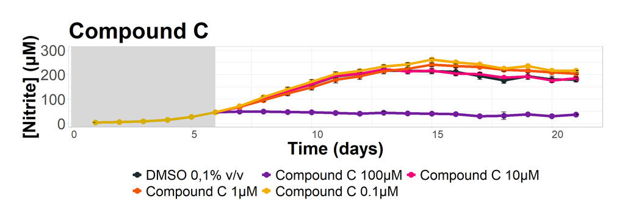

```r
# Let's inspect one activity plot
activity_plots_list[3]
```

Step 7: We can create a panel for our plots, placing the positive control first. For this, we can create a grid.

```r
library(grid)
library(gridExtra)

# As we may need an empty space in the grid for symmetry reasons, we will also create an empty plot
empty_plot <- ggplot() + theme_void()
empty_plot <- list(empty_plot)

# We will create new list, putting the positive control plot first. We suggest doing this manually, by inspecting the activity plots list and using the numerical indices, like here. The empty plot can be put last
activity_plots_list_2 <- list(plot= c(activity_plots_list[7], activity_plots_list[1], activity_plots_list[2], activity_plots_list[3], activity_plots_list[4], activity_plots_list[5], activity_plots_list[6], empty_plot))
activity_plots_list_2 <- unlist(activity_plots_list_2, recursive = F)

# We can create a plot arrangement out of the order of the list. It will be a 4 rows x 2 columns grid arrangement, with the heights of all rows being the same
plot_arranged_A <- grid.arrange(grobs = activity_plots_list_2, ncol = 2, nrow = 4, heights = c(1.5,1.5,1.5,1.5))
```

[figure not shown]

```r
# We print the panel in a .pdf file
cairo_pdf("Activity_Plots.pdf", onefile = T, height = 44, width = 42)
grid.draw(plot_arranged_A)
dev.off()
```

Thanks a lot for using this code!

Remember to always cite the author of the code you use!

And buy a programmer a beer 🍺 ! They really need one!